# investigating a movie dataset from TMDB

# Exploratory Data Analysis

Now lets perform some exploratory data analisys on our cleaned data frame and find out answer to questions

```python
movie_df.head()
```

|  | id | popularity | budget | revenue | original_title | director | runtime | genres | vote_count | vote_average |
| --- | --- | --- | --- | --- | --- | --- | --- | --- | --- | --- |
| 0 | 135397 | 32.985763 | 150000000 | 1513528810 | Jurassic World | Colin Trevorrow | 124 | Action\|Adventure\|Science Fiction\|Thriller | 5562 | 6.5 |
| 1 | 76341 | 28.419936 | 150000000 | 378436354 | Mad Max: Fury Road | George Miller | 120 | Action\|Adventure\|Science Fiction\|Thriller | 6185 | 7.1 |
| 2 | 262500 | 13.112507 | 110000000 | 295238201 | Insurgent | Robert Schwentke | 119 | Adventure\|Science Fiction\|Thriller | 2480 | 6.3 |
| 3 | 140607 | 11.173104 | 200000000 | 2068178225 | Star Wars: The Force Awakens | J.J. Abrams | 136 | Action\|Adventure\|Science Fiction\|Fantasy | 5292 | 7.5 |
| 4 | 168259 | 9.335014 | 190000000 | 1506249360 | Furious 7 | James Wan | 137 | Action\|Crime\|Thriller | 2947 | 7.3 |

```
count    3823.000000
mean        1.197585
std         1.479421
min         0.001117
25%         0.465100
50%         0.804348
75%         1.380228
max        32.985763
Name: popularity, dtype: float64
```

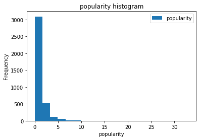

```python
# now lets devide the popularity category
movie_df.popularity.plot(kind='hist',bins=20);
plt.xlabel('popularity')
plt.title('popularity histogram')
plt.legend();
movie_df.popularity.describe()
```

```python
more_popular = movie_df.popularity >= 5
less_popular = movie_df.popularity < 5
```

since we are concentrating more on popularity of movies in our analysis, It is good to have a popularity rank column in a dataframe stating whether the movie is more popular or less popular

```python
# lets create function which can compare values in a series and create new values, and append those
# values as a new column to the movie_df data frame
def category_creator(series_name, new_column_name, threshold_value):
    ''' This function compares each value in the given series with the threshold value
    and gives whether the values is more category name or less category name
    and append all the new values to a new series column and add the column
    to the movie_df dataframe'''
    new_list = []
    iterator1 = movie_df
    for x in movie_df[series_name].values:
        if x >= threshold_value:
            new_list.append('more {}'.format(series_name))
        else:
            new_list.append('less {}'.format(series_name))
    movie_df[new_column_name] = new_list
```

```python
#calling the category_creator function to create popularity_rank column
category_creator('popularity', 'popularity_rank', 5)
```

```python
# lets check whether the new popularity rank column was created
movie_df.head()
```

|  | id | popularity | budget | revenue | original_title | director | runtime | genres | vote_count | vote_average | popularity_rank |
| --- | --- | --- | --- | --- | --- | --- | --- | --- | --- | --- | --- |
| 0 | 135397 | 32.985763 | 150000000 | 1513528810 | Jurassic World | Colin Trevorrow | 124 | Action\|Adventure\|Science Fiction\|Thriller | 5562 | 6.5 | more popularity |
| 1 | 76341 | 28.419936 | 150000000 | 378436354 | Mad Max: Fury Road | George Miller | 120 | Action\|Adventure\|Science Fiction\|Thriller | 6185 | 7.1 | more popularity |
| 2 | 262500 | 13.112507 | 110000000 | 295238201 | Insurgent | Robert Schwentke | 119 | Adventure\|Science Fiction\|Thriller | 2480 | 6.3 | more popularity |
| 3 | 140607 | 11.173104 | 200000000 | 2068178225 | Star Wars: The Force Awakens | J.J. Abrams | 136 | Action\|Adventure\|Science Fiction\|Fantasy | 5292 | 7.5 | more popularity |
| 4 | 168259 | 9.335014 | 190000000 | 1506249360 | Furious 7 | James Wan | 137 | Action\|Crime\|Thriller | 2947 | 7.3 | more popularity |

# relation of popularity vs budget

```python
# lets see whether popularity comes from the budget of the movies
# lets classify between high budget movies and low budget movies,
# considering all movies has budget i.e greter than mean of budget of all values, then it is in high budget category
# otherwise in low budget category,
# calling the category_creator fuction to create new column budget rank
category_creator('budget', 'budget_rank', movie_df.budget.mean())
```

```python
# lets see whether the new new budget_rank column was created
movie_df.head()
```

|  | id | popularity | budget | revenue | original_title | director | runtime | genres | vote_count | vote_average | popularity_rank | budget_rank |
| --- | --- | --- | --- | --- | --- | --- | --- | --- | --- | --- | --- | --- |
| 0 | 135397 | 32.985763 | 150000000 | 1513528810 | Jurassic World | Colin Trevorrow | 124 | Action\|Adventure\|Science Fiction\|Thriller | 5562 | 6.5 | more popularity | more budget |
| 1 | 76341 | 28.419936 | 150000000 | 378436354 | Mad Max: Fury Road | George Miller | 120 | Action\|Adventure\|Science Fiction\|Thriller | 6185 | 7.1 | more popularity | more budget |
| 2 | 262500 | 13.112507 | 110000000 | 295238201 | Insurgent | Robert Schwentke | 119 | Adventure\|Science Fiction\|Thriller | 2480 | 6.3 | more popularity | more budget |
| 3 | 140607 | 11.173104 | 200000000 | 2068178225 | Star Wars: The Force Awakens | J.J. Abrams | 136 | Action\|Adventure\|Science Fiction\|Fantasy | 5292 | 7.5 | more popularity | more budget |
| 4 | 168259 | 9.335014 | 190000000 | 1506249360 | Furious 7 | James Wan | 137 | Action\|Crime\|Thriller | 2947 | 7.3 | more popularity | more budget |

```python
# median popularity for high budget movies
movie_df[movie_df.budget_rank == 'more budget'].popularity.median()
```

```
1.22837
```

```python
# median popularity of low budget movies
movie_df[movie_df.budget_rank == 'less budget'].popularity.median()
```

```
0.6429720000000001
```

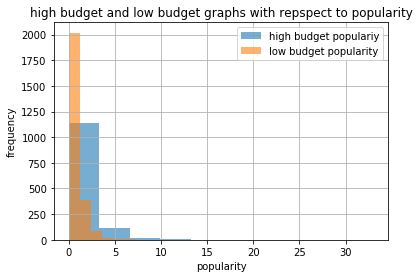

```python
# seems like there is a difference in popularity in low budget and high budget movies
#lets see them visually
movie_df[movie_df.budget_rank == 'more budget'].popularity.hist(alpha = 0.6, label='high budget populariy')
movie_df[movie_df.budget_rank == 'less budget'].popularity.hist(alpha = 0.6, label='low budget popularity')
plt.xlabel('popularity')
plt.ylabel('frequency')
plt.title('high budget and low budget graphs with repspect to popularity')
plt.legend();
```

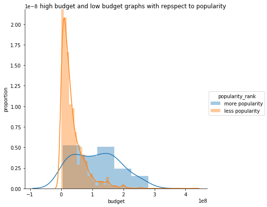

```python
sns.FacetGrid(movie_df,hue='popularity_rank',size=6).map(sns.distplot, 'budget').add_legend();
plt.ylabel('proportion')
plt.suptitle('high budget and low budget graphs with repspect to popularity');
```

### observation

**from above graph we can see high budget movies are skewed to right and recieving good popularity than low budget movies**

# relation between popularity and revenue

```python
#median of revenue for more popular movies
movie_df[more_popular].revenue.median()
```

```
521311860.0
```

```python
# median of revenue for less popular movies
movie_df[less_popular].revenue.median()
```

```
43598074.5
```

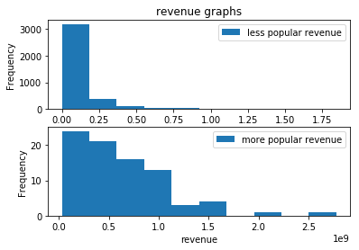

```python
# seems like there is a good difference between revenues of more popular movies and less popular movies
# lets visualize them
plt.figure(1)
plt.subplot(211)
movie_df[less_popular].revenue.plot(kind='hist',label='less popular revenue')
plt.xlabel('revenue')
plt.legend()
plt.title('revenue graphs')
plt.subplot(212)
movie_df[more_popular].revenue.plot(kind='hist',label='more popular revenue')
plt.xlabel('revenue')
plt.legend();
```

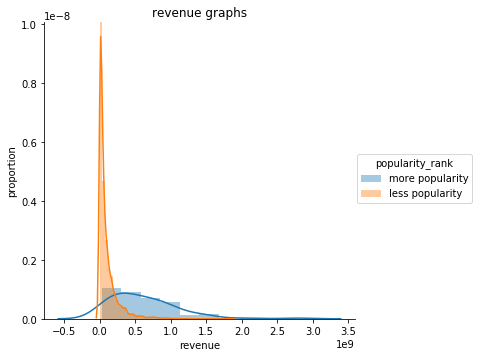

```python
sns.FacetGrid(movie_df,hue='popularity_rank',size=5).map(sns.distplot, 'revenue').add_legend();
plt.ylabel('proportion')
plt.title('revenue graphs');
```

### observation

**from the above graph and median values we can say that more popular movies is more skewed to the right, and also has greater median values resulting it has more revenue than less popular movies,**

# relation between popularity and vote_count

```python
movie_df[more_popular].vote_count.mean()
```

```
3899.0843373493976
```

```python
movie_df[less_popular].vote_count.mean()
```

```
456.5887700534759
```

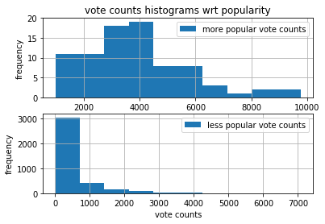

```python
plt.figure(1)
plt.subplot(211)
plt.title('vote counts histograms wrt popularity')
plt.ylabel('frequency')
movie_df[more_popular].vote_count.hist(label='more popular vote counts')
plt.legend()
plt.subplot(212)
plt.ylabel('frequency')
movie_df[less_popular].vote_count.hist(label='less popular vote counts')
plt.xlabel('vote counts')
plt.legend();
```

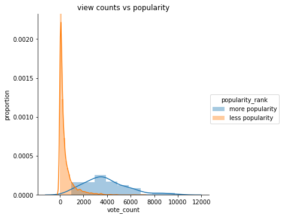

```python
sns.FacetGrid(movie_df, hue='popularity_rank', size=5).map(sns.distplot, 'vote_count').add_legend()
plt.ylabel('proportion')
plt.title('view counts vs popularity');
```

```python
# which genres are made most
genres_counts = movie_df.genres.value_counts()
genres_counts.describe()
```

```
count    1049.000000
mean        3.644423
std        12.906681
min         1.000000
25%         1.000000
50%         1.000000
75%         2.000000
max       244.000000
Name: genres, dtype: float64
```

```python
# since the mean is 3.6, whereas 75% value is 2.0 and max is 244,
# I am only considering the genres that are made more than 20 times, to calculate which genre is made most
genre_values = genres_counts.sort_values(ascending=False)
genre_20 = genre_values[genre_values >= 20]
genre_20
```

```
Drama                          244
Comedy                         232
Drama|Romance                  106
Comedy|Romance                 101
Comedy|Drama|Romance            90
Comedy|Drama                    87
Horror|Thriller                 79
Horror                          58
Drama|Thriller                  48
Action|Thriller                 39
Crime|Drama|Thriller            37
Drama|Comedy                    35
Comedy|Family                   32
Action|Crime|Thriller           30
Drama|Crime                     27
Drama|History                   27
Crime|Drama                     26
Action|Crime|Drama|Thriller     25
Drama|Comedy|Romance            25
Thriller                        25
Adventure|Action|Thriller       22
Action|Thriller|Crime           22
Documentary                     22
Comedy|Crime                    22
Action                          21
Horror|Mystery|Thriller         21
Action|Comedy                   20
Name: genres, dtype: int64
```

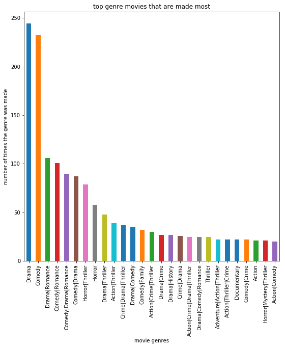

```python
genre_20.plot(kind='bar', figsize=(9,9))
plt.xlabel('movie genres')
plt.ylabel('number of times the genre was made')
plt.title('top genre movies that are made most');
```

# observation

As we can see from the above bar graph, seems like drama genre was preferred by most of the directors, followed by comedy

# relation between popularity and runtime of the movies

```python
# lets see whether the popularity is coming from the runtime of the movie
movie_df[more_popular]['runtime'].mean()
```

```
129.55421686746988
```

```python
movie_df[less_popular]['runtime'].mean()
```

```
108.85588235294118
```

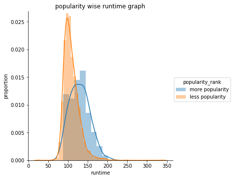

```python
# lets get a clear view by graphs
sns.FacetGrid(movie_df, hue='popularity_rank', size=5).map(sns.distplot,'runtime').add_legend();
plt.ylabel('proportion')
plt.title('popularity wise runtime graph');
```

### observation

```python
# we can also see the relationship between budget and revenue,for high popularity and low popularity
#movies below
```

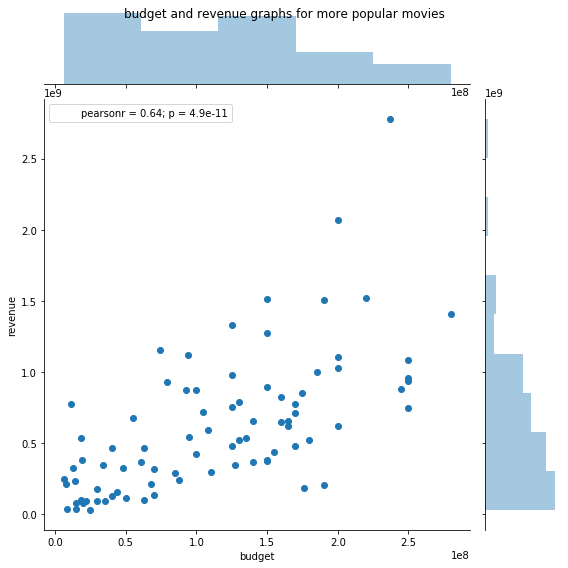

```python
sns.jointplot(x='budget', y='revenue', data=movie_df[more_popular], size=8)
plt.suptitle('budget and revenue graphs for more popular movies');
```

[output not shown]

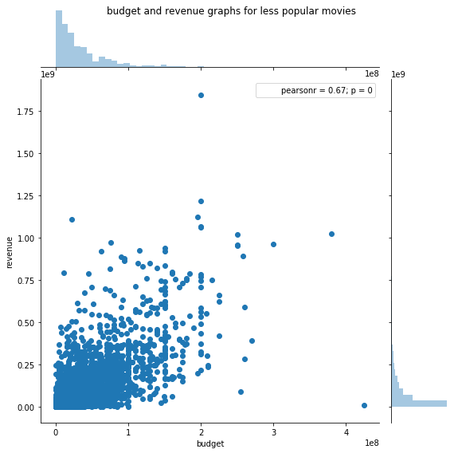

```python
sns.jointplot(x='budget', y='revenue', data=movie_df[less_popular], size=8)
plt.suptitle('budget and revenue graphs for less popular movies')
```

**we can also see a positive corelation between budget,revenue,vote count factors and popularity in the below scatter matrix**

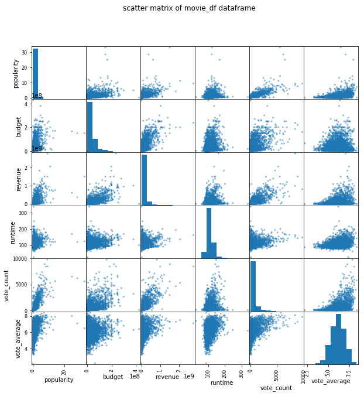

```python
pd.plotting.scatter_matrix(movie_df, figsize=(10,10))
plt.suptitle('scatter matrix of movie_df dataframe');
```

# conclusion

Based on the above analysis we can say that, there is a corelation between popularity and budget, revenue, and vote counts of the movies generally, high budget, high revenue movies, and also high vote counts movies are more popular than low budget, low revenue and less vote count movies,

based on the graphs we can say, that vote count is one feature which differentiates very well the popularity, rather than others, like budget,revenue and runtime

Drama genre movies are made most, followed by the comedy movies, looks like these two genres are most liked by directors out of all genres

# limitations

the above conclusions and observations are not 100 percent accurate, they are correct most of the times, but can deviate in some cases, one of the reason for the limitation is missing values also many values in budget and revenue columns doesn't make sense, so they are dropped , which may alters small percent of our results

# Resources: NA